# Part II - Prosper Loan Data Explanatory Visualization Presentation

## by Isaac Mwendwa

## Investigation Overview

#### Goals of Presentation

- The goal of the presentation is to provide explanations into the insights from the exploratory visualization (Part 1).
- The presentation will thus be coupled with exploratory visualizations and explanation of insights - to yield explanatory visualizations.
- The visualizations in this section will be more polished as compared to those in Part 1

#### Summary of Key Insights to be Explored

Distribution of Debt-to-Income Ratio

- The distribution is skewed right, implying that the majority of the Debt-to-Income ratios lay between 0 and 0.4

Effect of Employment Status on Borrower APR

Loan Original Amount vs. Income Range

#### Summary of Key Insights to be Explored (Continued)

Loan Original Amount vs. Loan Term and Prosper Score

- The Loan Original Amount increases as the Prosper Score increases, and also as the Loan Term increases

Prosper Score vs. Borrower APR and Loan Original Amount

- The Loan Original Amount increases with an increase in the Prosper Score and a decrease in Borrower APR
- When the Prosper Score is above 9 (best score/lowest risk) and the Loan Original Amount increases; there is an abnormal behaviour of the Borrower APR increasing

## Dataset Overview

- The Loan Data from Prosper Dataset is a dataset of loans taken between 2005 and 2013 from Prosper
- The dataset contains 113,937 rows (loans) with 81 columns (loan variables) on each row
- The loan variables consist of qualitative (ordinal and nominal) and quantitative features
- The main features of interest (response variables) in the dataset include:
  > - Borrower's APR
  > - Prosper Score
  > - Debt to Income Ratio
- The variables that will support the investigation of the variables of interest are known as predictor features. They include:
  > - Income Range
  > - Employment Status
  > - Stated Monthly Income
  > - Loan Year
  > - Employment Duration

## Visualization 1: What is the Distribution of Debt-to-Income Ratio?

#### Introduction

Definition: **Debt-to-Income Ratio**

- The Debt-to-Income (DTI) ratio divides a borrower's total monthly debt payments by their gross monthly income
- Lenders use DTI — along with credit history and other factors — to evaluate a borrower's financial ability to repay a loan

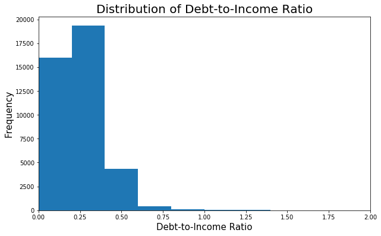

#### **Insights from Visualization**

- The distribution is skewed right, implying that the majority of the Debt-to-Income ratios lay between 0 and 0.4
- This implies that lenders pay keen attention to ensure a borrower can service the loan, by ensuring that their Debt-to-Income ratio is low
- A low Debt-to-Icome ratio shows that the borrower has more money at their disposal, and hence they can fully repay the loan taken

## Visualization 2: What is the effect of Employment Status on Borrower APR?

#### Introduction

Definition: **Borrower APR**

- The Borrower's Annual Percentage Rate (APR) for the loan

Definition: **Employment Status**

- The employment status of the borrower at the time they posted the listing

We would like to know the influence of Employment Status on a Borrower's APR in this section.

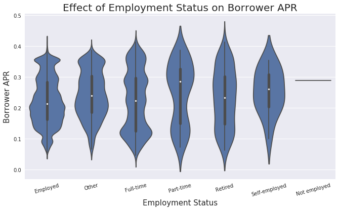

## Visualization 3: How does the Loan Original Amount compare with the Income Range?

#### Introduction

Definition: **Loan Original Amount**

- The origination amount of the loan (also known as Loan Principal)

Definition: **Income Range**

- The income range of the borrower at the time the listing was created

In this section, We would like to know the influence of a borrower's Income Range on the Loan Original Amount.

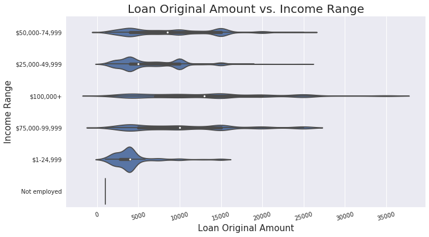

#### **Insights from Visualization**

- The plot shows that the people with the highest Loan Original Amount are borrowers in the Income Range of USD 100,000+ and USD 75k - USD 100k
- The borrowers with the least Loan Original Amount are in the Income Ranges of "Not employed" and "USD 1 - USD 25k"
- Therefore, there is a positive relationship between the Income Range and the Loan Original Amount
- This implies that the more you earn, the more you can borrow

## Visualization 4: How does the Loan Original Amount relate with Loan Term and Prosper Score?

#### Introduction

Definition: **Prosper Score**

Definition: **Loan Term**

- The length of the loan expressed in months

Definition: **Loan Original Amount**

- The origination amount of the loan (also known as Loan Principal)

We would like to know the influence of Loan Term and Prosper Score on the Loan Original Amount in this section.

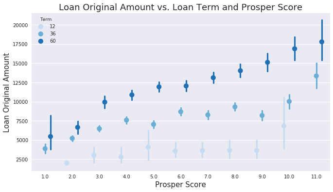

#### **Insights from Visualization**

- The key observation from the plot above is that the Loan Original Amount shares a positive relationship with the Prosper Score and the Loan Term
- The plot shows that the Loan Original Amount increases as the Prosper Score increases, and also as the Loan Term increases
- This can be explained by the fact that for a loan to have a longer term, then the loan original amount (Principal) must be bigger.
- Additionally, for a borrower to qualify for a bigger loan (and hence a bigger repayment term), then they should have a good (increasing) Prosper Score

## Visualization 5: Effect of Prosper Score on Borrower APR and Loan Original Amount

#### Introduction

Definition: **Borrower APR**

- The Borrower's Annual Percentage Rate (APR) for the loan

Definition: **Prosper Score**

Definition: **Loan Original Amount**

- The origination amount of the loan (also known as Loan Principal)

We would like to know the influence of Prosper Score on a Borrower's APR and the Loan Original Amount in this section.

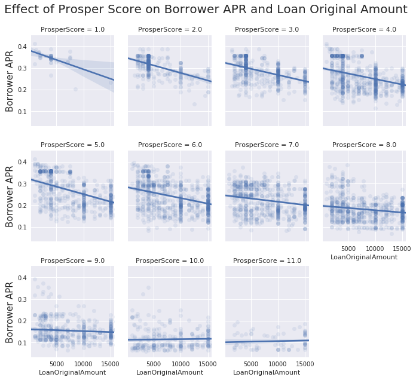

#### **Insights from Visualization**

- The plots show that the Loan Original Amount increases with an increase in the Prosper Score and a decrease in Borrower APR (which is true by convention)
  > - However, there is an interesting and surprising observation from the three features
  > - When the Prosper Score is above 9 (best score/lowest risk) and the Loan Original Amount increases; there is an abnormal behaviour of the Borrower APR increasing
  > - This can be explained in part by the propensity of people with better Prosper Scores borrowing bigger loans; which creates a high demand for the loans; and a corresponding increase in Borrower APR
  > - The anomalous observation can be attributed to the maximizing on loan profits by the lenders, going by the Law of Supply and Demand